# qc and analysis of single nuc-seq data (alsf-filbin)

### Distribution of pre-mRNA

```r
summary(colSums(dat_prem))
```

```
##    Min. 1st Qu.  Median    Mean 3rd Qu.    Max.
##    1874    9792   19224   23103   31305  206626
```

```r
# Apply transformation
n = round(median(colSums(dat_prem)))
dat_prem = apply(dat_prem, MARGIN = 2, function(x) x*n/sum(x))

summary(colSums(dat_prem))
```

```
##    Min. 1st Qu.  Median    Mean 3rd Qu.    Max.
##   19224   19224   19224   19224   19224   19224
```

I plot the mean and variance for every row (transcript). Under a poisson distribution, they should be the same.

```r
plot_meanvar = function(dat_sub){
  # estimate lambdas and variances for every transcript
  means = rowMeans(dat_sub)
  vars = apply(dat_sub, MARGIN = 1, var)

  # variance = mean under Poisson distribution
  tibble(means, vars) %>%
    ggplot(aes(x = log(means), y = log(vars))) +
    geom_point(alpha = 0.4) +
    geom_abline(intercept = 0, slope = 1)
}
```

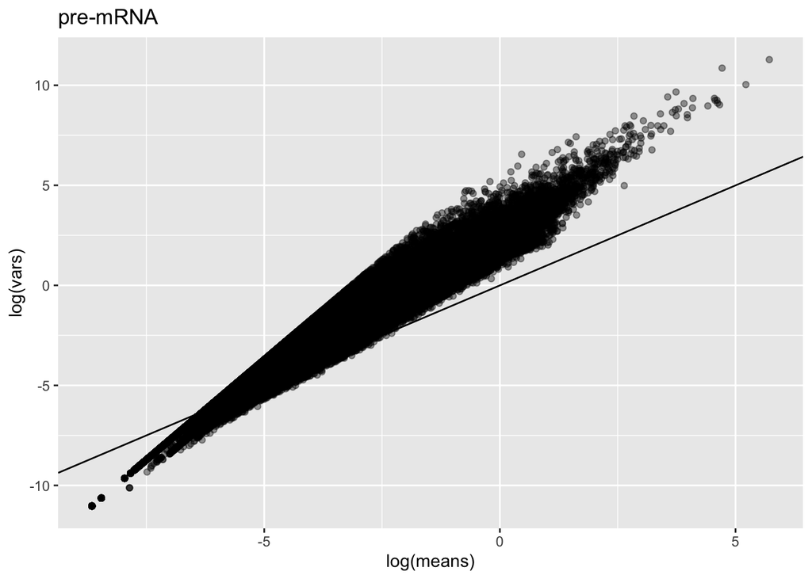

```r
plot_meanvar(dat_prem) +
  labs(title = "pre-mRNA")
```

I first compute the average expression for every row (x-axis) $\hat{\mu}_i$ and the empirical $P(X_i=0)$, which is the probability that for a given transcript $i$, the count is 0.

I then compute what $P(X_i=0)$ would be under the model assumptions of binomial or poisson, using parameters estimated from the data. In particular, for a $Binom(n, p_i)$, $n$ is the median number of total counts of cells and $p_i$ is the mean proportion of counts that were in gene $i$.

```r
# Function to plot P(X_i = 0) against average expression level mu_i
plot_prob = function(dat_sub){
  n = round(median(colSums(dat_sub)))
  means = rowMeans(dat_sub)
  vars = apply(dat_sub, MARGIN = 1, var)

  # empirical P(X_i = 0)
  emp_probs_0 = apply(dat_sub, MARGIN = 1, function(r) sum(r==0)/ncol(dat_sub))
  plot_dt = tibble(means, emp_probs_0)

  emp_props = rowMeans(dat_sub/colSums(dat_sub))
  # Model P(X_i = 0) under Binomial
  binom_probs_0 = dbinom(x = 0, size = n, prob = emp_props)
  # Model P(X_i = 0) under Poisson
  poiss_probs_0 = dpois(x = 0, lambda = n*emp_props)
  # Model P(X_i = 0) under Negative Binomial
  # Estimate size/dispersion parameter
  model = lm(vars ~ 1*means + I(means^2) + 0, tibble(means, vars))
  phi = 1/coef(model)["I(means^2)"]
  nbinom_probs_0 = dnbinom(x = 0, size = phi, mu = n*emp_props)

  # Tibble for plot
  plot_lines_dt = tibble(means = means,
                         binomial = binom_probs_0,
                         poisson = poiss_probs_0,
                         nbinomial = nbinom_probs_0) %>%
    pivot_longer(-means, names_to = "model", values_to = "probs_0")

  # Plot
  plt = plot_lines_dt %>%
    ggplot(aes(x = log(means), y = probs_0)) +
    geom_point(data = plot_dt, aes(x = log(means), y = emp_probs_0), alpha = 0.4) + # Add data points
    geom_line(aes(color = model)) + # Add lines for models
    labs(x = "Average expression level log(E(X_i))",
         y = "P(X_i = 0)")

  # Return object
  out = list(plot = plt,
             lines_dt = plot_lines_dt)
  return(out)
}
```

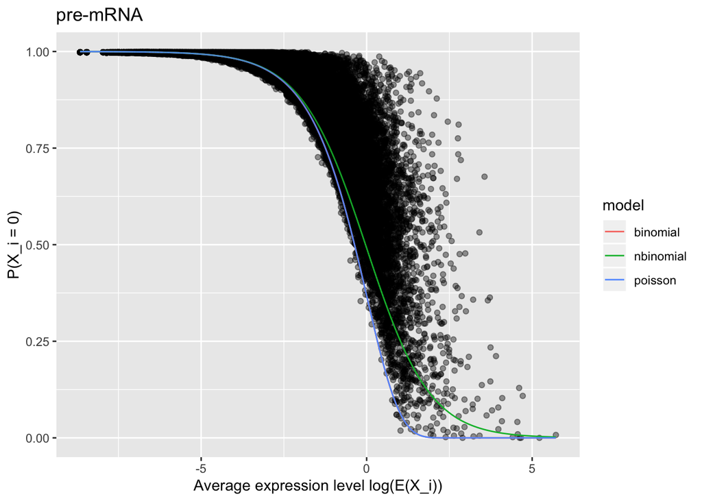

```r
# Plot P(X_i = 0) against average expression level
prob_out_prem = plot_prob(dat_prem)
prob_out_prem$plot +
  labs(title = "pre-mRNA")
```

```r
# qqplot for first row
qprobs = seq(0.01, 0.99, by = 0.01)
plot(quantile(rpois(1000, lambda = lambdas[1]), qprobs),
     quantile(dat_prem[,1], probs = qprobs))
```

[output not shown]

### Distribution of mRNA

```r
summary(colSums(dat_mrna))
```

```
##    Min. 1st Qu.  Median    Mean 3rd Qu.    Max.
##     329    3054    6915   10115   13454   81420
```

```r
# Apply transformation
n = round(median(colSums(dat_mrna)))
dat_mrna = apply(dat_mrna, MARGIN = 2, function(x) x*n/sum(x))

summary(colSums(dat_mrna))
```

```
##    Min. 1st Qu.  Median    Mean 3rd Qu.    Max.
##    6915    6915    6915    6915    6915    6915
```

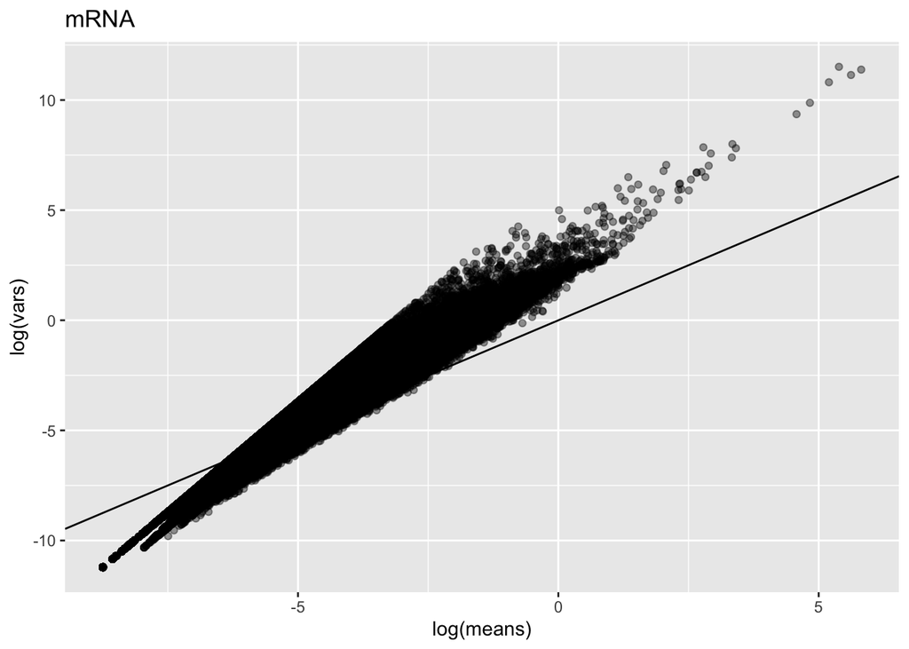

```r
# Plot mean against variance
plot_meanvar(dat_mrna) +
  labs(title = "mRNA")
```

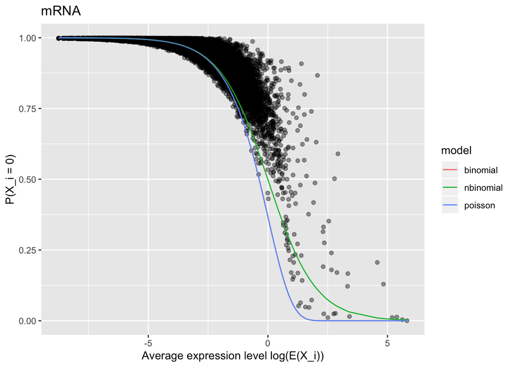

```r
# Plot P(X_i = 0) against average expression level
prob_out_mrna = plot_prob(dat_mrna)
prob_out_mrna$plot +
  labs(title = "mRNA")
```

### Distribution of combined pre-mRNA and mRNA counts

```r
# Combine pre-mRNA and mRNA counts
dim(dat_prem) # 99845 x 534
```

```
## [1] 74384   534
```

```r
dim(dat_mrna) # 226608 x 534
```

```
## [1] 165030    534
```

```r
transcript_names = gsub(".{8}$", "" , rownames(dat_prem)) # length = 99845
transcript_names = intersect(transcript_names, rownames(dat_mrna)) # length = 99771
premrna_names = paste(transcript_names, "premrna", sep = ".")

# Check that the rows of pre-mRNA and mRNA are in the same exact order
tmp1 = gsub(".{8}$", "", rownames(dat_prem[premrna_names,]))
tmp2 = rownames(dat_mrna[transcript_names,])
identical(tmp1, tmp2)
```

```
## [1] TRUE
```

```r
# Add counts for pre-mRNA and mRNA element-wise
dat_combined = dat_prem[premrna_names,] + dat_mrna[transcript_names,]
rownames(dat_combined) = transcript_names
```

```r
summary(colSums(dat_combined))
```

```
##    Min. 1st Qu.  Median    Mean 3rd Qu.    Max.
##   16473   17532   18135   18219   18858   20724
```

```r
# Apply transformation
n = round(median(colSums(dat_combined)))
dat_combined = apply(dat_combined, MARGIN = 2, function(x) x*n/sum(x))

summary(colSums(dat_combined))
```

```
##    Min. 1st Qu.  Median    Mean 3rd Qu.    Max.
##   18135   18135   18135   18135   18135   18135
```

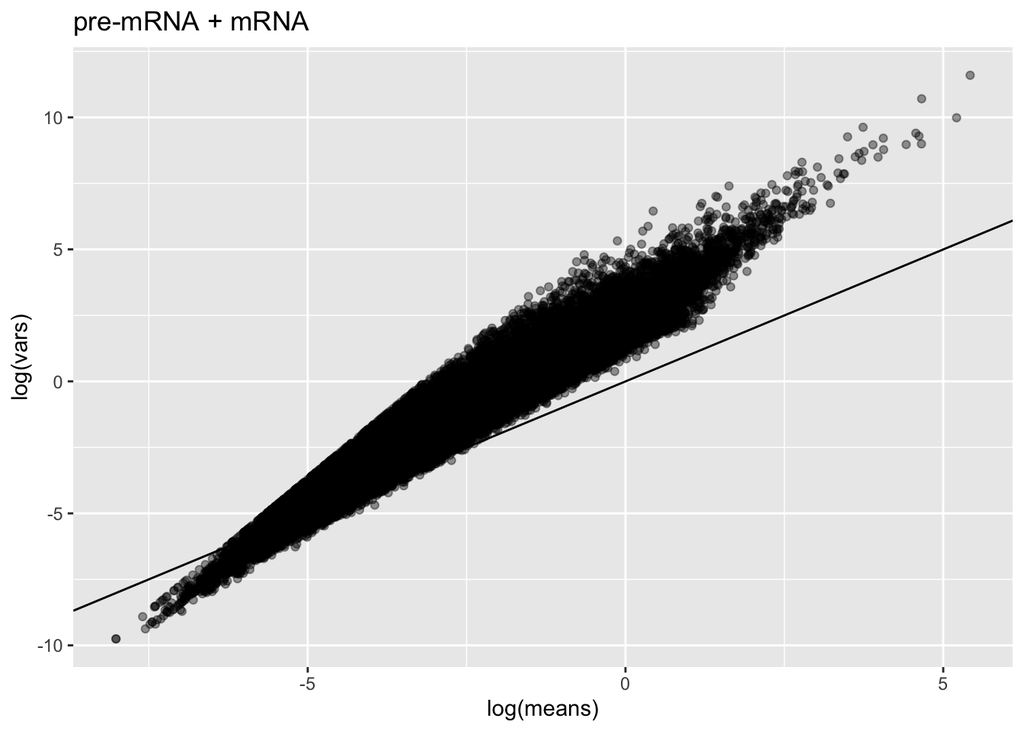

```r
# Plot mean against variance
plot_meanvar(dat_combined) +
  labs(title = "pre-mRNA + mRNA")
```

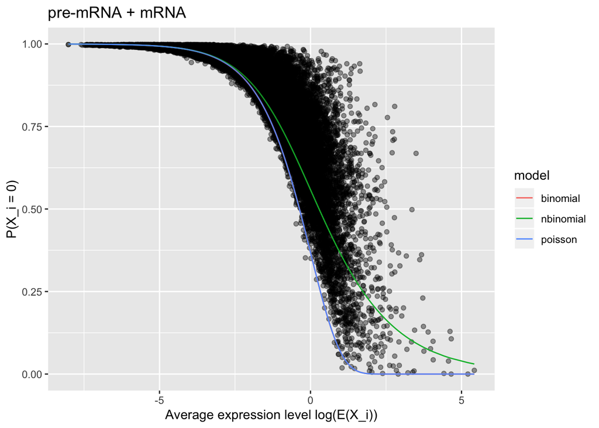

```r
# Plot P(X_i = 0) against average expression level
prob_out_combined = plot_prob(dat_combined)
prob_out_combined$plot +
  labs(title = "pre-mRNA + mRNA")
```

### Combined plot

```r
lines_prem_dt = prob_out_prem$lines_dt %>%
  mutate(data = "pre-mRNA")
lines_mrna_dt = prob_out_mrna$lines_dt %>%
  mutate(data = "mRNA")
lines_combined_dt = prob_out_combined$lines_dt %>%
  mutate(data = "combined")

lines_all_dt = bind_rows(lines_prem_dt, lines_mrna_dt, lines_combined_dt)
```

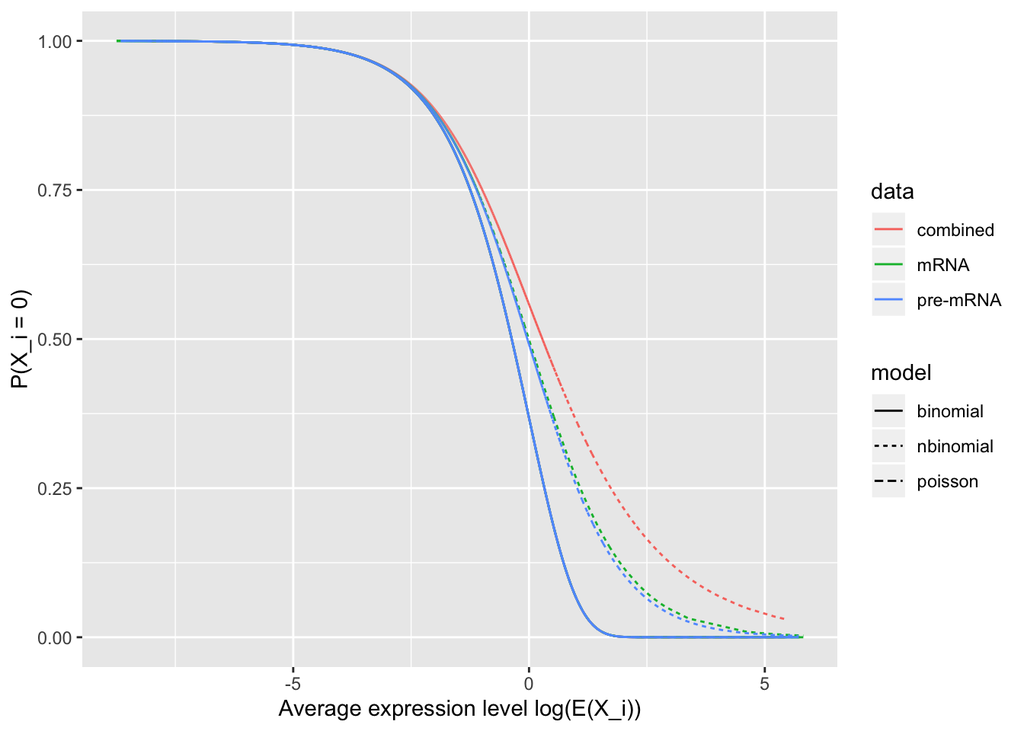

```r
lines_all_dt %>%
  ggplot(aes(x = log(means), y = probs_0)) +
  geom_line(aes(color = data, linetype = model)) +
  labs(x = "Average expression level log(E(X_i))",
         y = "P(X_i = 0)")
```

## PCA

```r
library(scran)
library(BiocSingular)
# library(factoextra)
library(tictoc)
library(glmpca)
```

```r
# Cells in each cluster are normalized separately
clust = quickCluster(dat_umi)
table(clust)
```

```
## clust
##   1   2   3
## 169 249 116
```

```r
deconv = computeSumFactors(dat_umi, cluster = clust)
```

```r
X = dat_umi %>%
  as.matrix() %>%
  sweep(., 2, deconv, "/") %>% # Divide by library size
  t()
X = log2(X + 1) # Apply log transformation

# Remove columns (transcripts) with zero variance
nonzero_var_cols = which(apply(X, 2, var) != 0)
X = X[, nonzero_var_cols]
```

```r
# Run approximate PCA (8 seconds)
tic("approx PCA")
pc = runPCA(X, rank = 5, BSPARAM = IrlbaParam())
toc()
```

```
## approx PCA: 9.377 sec elapsed
```

```r
# set.seed(1)
# Run random PCA (2 minutes)
# tic("random PCA")
# pc = runPCA(X, rank = 5, BSPARAM = RandomParam())
# toc()

# Run PCA with prcomp (~10 minutes)
# pc = prcomp(X, center = T, scale = F)
# % variance explained by each PC
# fviz_eig(pc)
```

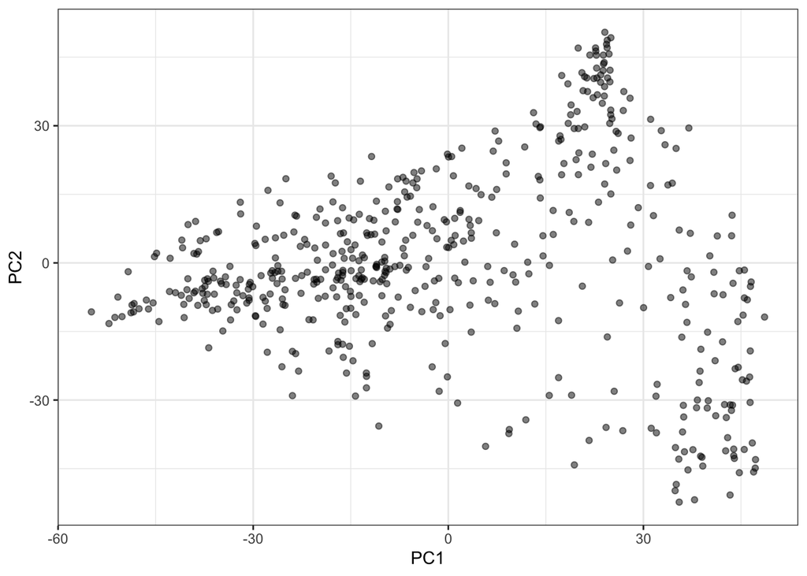

```r
# Plot PC
data.frame(PC1 = pc$x[,1], PC2 = pc$x[,2]) %>%
  ggplot(aes(PC1, PC2)) +
  geom_point(alpha = 0.5) +
  theme_bw()
```

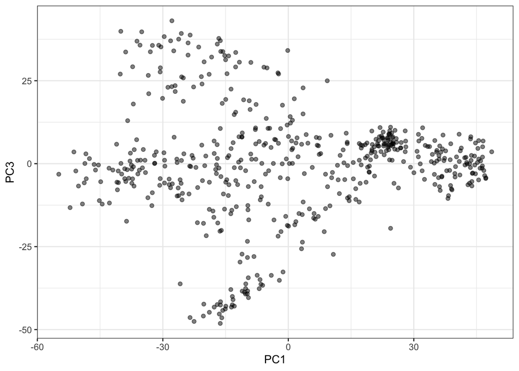

```r
data.frame(PC1 = pc$x[,1], PC3 = pc$x[,3]) %>%
  ggplot(aes(PC1, PC3)) +
  geom_point(alpha = 0.5) +
  theme_bw()
```

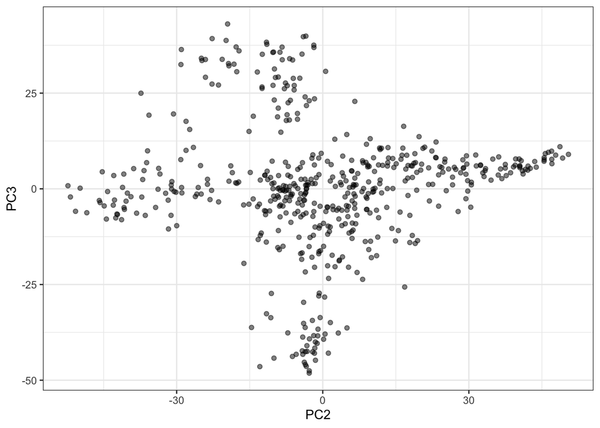

```r
data.frame(PC2 = pc$x[,2], PC3 = pc$x[,3]) %>%
  ggplot(aes(PC2, PC3)) +
  geom_point(alpha = 0.5) +
  theme_bw()
```

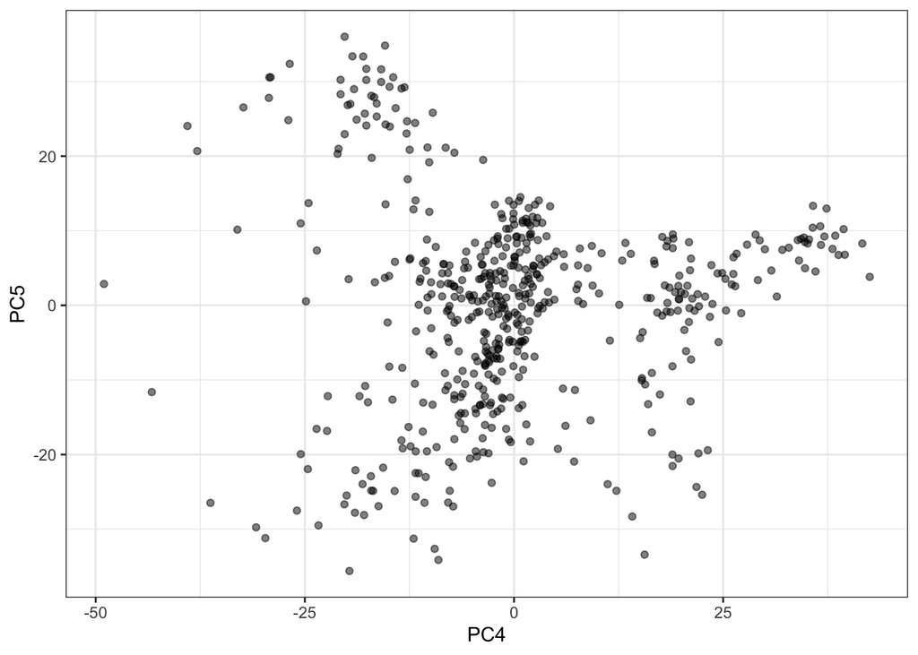

```r
data.frame(PC4 = pc$x[,4], PC5 = pc$x[,5]) %>%
  ggplot(aes(PC4, PC5)) +
  geom_point(alpha = 0.5) +
  theme_bw()
```

### GLM-PCA

```r
# Takes a long time, may want to try on cluster
tic("glm PCA")
glmpca(dat_umi %>% as.matrix(), L = 5, fam = c("poi"))
toc()
```